# (Yugi-Oh cards Dataset)

## by (Mustafa Mahmoud Nadeem)

## Preliminary Wrangling

This is a dataset containing all cards in Yugi-Oh card game. game board is 4 *5, 2* 5 for each player 1 row for attacking monsters and back row for trap and spell cards and 3 extra places for fusion cards, cemetery and board effect cards. game has 5 phases: 1- standby phase : some effect cards can take action in this phase, skipping draw phase for example

2- draw phase: draw a card from your deck, some cards can take action here, draw extra card for example

3- main phase 1: put a card on the board in attack or defense position. only one card in attack row and unlimited cards in back row

4- battle phase: attack ur opponent.

5- main phase 2: put a card or change position if not used on main phase 1

6- end turn

### Its Time to Duel

```python
# import all packages and set plots to be embedded inline
import numpy as np
import pandas as pd
import matplotlib.pyplot as plt
import seaborn as sb

%matplotlib inline


df = pd.read_csv('card_data.csv')
df.head()
```

|  | Name | Type | Level | Race | Attribute | ATK | DEF |
| --- | --- | --- | --- | --- | --- | --- | --- |
| 0 | Limit Reverse | Trap Card | NaN | Continuous | NaN | NaN | NaN |
| 1 | The 13th Grave | Normal Monster | 3.0 | Zombie | DARK | 1200.0 | 900.0 |
| 2 | Gem-Enhancement | Trap Card | NaN | Normal | NaN | NaN | NaN |
| 3 | Magician's Circle | Trap Card | NaN | Normal | NaN | NaN | NaN |
| 4 | Castle of Dark Illusions | Flip Effect Monster | 4.0 | Fiend | DARK | 920.0 | 1930.0 |

```python
df.duplicated().sum()
```

```
85
```

```python
df.drop_duplicates(inplace = True)
```

```python
df.info()
```

```
<class 'pandas.core.frame.DataFrame'>
Int64Index: 6449 entries, 0 to 6522
Data columns (total 7 columns):
 #   Column     Non-Null Count  Dtype
---  ------     --------------  -----
 0   Name       6449 non-null   object
 1   Type       6449 non-null   object
 2   Level      4215 non-null   float64
 3   Race       6449 non-null   object
 4   Attribute  4215 non-null   object
 5   ATK        4215 non-null   float64
 6   DEF        4215 non-null   float64
dtypes: float64(3), object(4)
memory usage: 403.1+ KB
```

```python
df.shape
```

```
(6449, 7)
```

```python
df.head()
```

|  | Name | Type | Level | Race | Attribute | ATK | DEF |
| --- | --- | --- | --- | --- | --- | --- | --- |
| 0 | Limit Reverse | Trap Card | NaN | Continuous | NaN | NaN | NaN |
| 1 | The 13th Grave | Normal Monster | 3.0 | Zombie | DARK | 1200.0 | 900.0 |
| 2 | Gem-Enhancement | Trap Card | NaN | Normal | NaN | NaN | NaN |
| 3 | Magician's Circle | Trap Card | NaN | Normal | NaN | NaN | NaN |
| 4 | Castle of Dark Illusions | Flip Effect Monster | 4.0 | Fiend | DARK | 920.0 | 1930.0 |

```python
df.columns
```

```
Index(['Name', 'Type', 'Level', 'Race', 'Attribute', 'ATK', 'DEF'], dtype='object')
```

```python
#changing columns names for easier graphing
df.columns=[ 'name', 'card_type', 'level', 'race', 'attribute', 'attack', 'defense']
df.head()
```

|  | name | card_type | level | race | attribute | attack | defense |
| --- | --- | --- | --- | --- | --- | --- | --- |
| 0 | Limit Reverse | Trap Card | NaN | Continuous | NaN | NaN | NaN |
| 1 | The 13th Grave | Normal Monster | 3.0 | Zombie | DARK | 1200.0 | 900.0 |
| 2 | Gem-Enhancement | Trap Card | NaN | Normal | NaN | NaN | NaN |
| 3 | Magician's Circle | Trap Card | NaN | Normal | NaN | NaN | NaN |
| 4 | Castle of Dark Illusions | Flip Effect Monster | 4.0 | Fiend | DARK | 920.0 | 1930.0 |

### What is/are the main feature(s) of interest in your dataset?

Type of the card, its Attack and Defense and its level

### What features in the dataset do you think will help support your investigation into your feature(s) of interest?

Level, Attack and Defense also going to check Type and race

## Univariate Exploration

Going to plot the data with and without the Null values

```python
df.level.value_counts()  #not including the nulls
```

```
4.0     1376
3.0      705
2.0      393
6.0      369
5.0      339
8.0      315
1.0      293
7.0      238
10.0     109
9.0       53
12.0      17
11.0       8
Name: level, dtype: int64
```

```python
# basic function to make count plots a lil easier.
def my_count_plot(df, x = None, y =None, order = None, title=''):
    ''' seaborn count plot for faster grpahing with all the basics assigned for faster grpahing
        and consistancy '''
    base_color = sb.color_palette()[0]
    sb.countplot(data = df , x=x , y=y, order= order, color = base_color)
    plt.title(title.title(), weight = 'bold')

# another basic func for faster axis renaming.
def my_axis(x = '', y='', title= ''):
    """ faster axis renaming and titles"""
    plt.xlabel(x.title(), weight = 'bold')
    plt.ylabel(y.title(), weight = 'bold')
    plt.title(title.title(), weight = 'bold')


def my_fig():
    '''adjusting fig size'''
    plt.figure(figsize=[14.70, 8.27]);
```

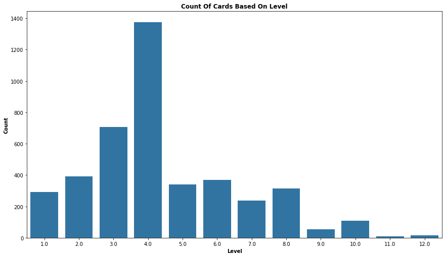

```python
my_fig()
my_count_plot(df, x='level')
my_axis(x='level', y ='count',title='Count of cards based on level')
```

As we can see here, Level 4 have the highest number of cards.

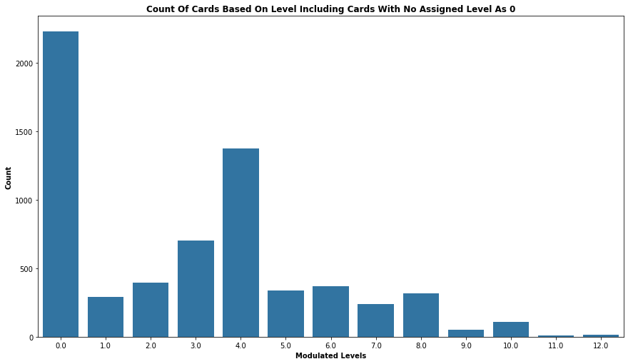

```python
my_fig()
df['modulation'] = df.level.fillna(0) # cards with no level changed to lvl 0
my_count_plot(df=df , x = 'modulation')
my_axis(x='modulated levels', y='count', title='Count of cards based on level including cards with no assigned level as 0')
```

Now adding the cards with no Level assigned, They are a lot so lets check their Types

```python
#Finding cards with no Level assiociated with them
no_level = df.query("modulation == 0")['card_type']
no_level.unique()
```

```
array(['Trap Card', 'Spell Card', 'Token'], dtype=object)
```

Trap Cards, Spell Cards, Tokens don't have a Level assigned to them but contribute heavily to the game play and I'm going to analyze the data without them since the description of what they do isn't available in the dataset.

```python
total_cards = df.shape[0]
lvl_count = df['modulation'].value_counts()
lvl_order = lvl_count.index
lvl_count
```

```
0.0     2234
4.0     1376
3.0      705
2.0      393
6.0      369
5.0      339
8.0      315
1.0      293
7.0      238
10.0     109
9.0       53
12.0      17
11.0       8
Name: modulation, dtype: int64
```

```python
# makinf the same graph with relative proportion for better Visualization
lvl_count = lvl_count[0]
max_percent = lvl_count / total_cards
```

```python
my_ticks = np.arange(0, max_percent+0.05, 0.05)
ticks_names = ['{:0.2f}'.format(x) for x in my_ticks]
```

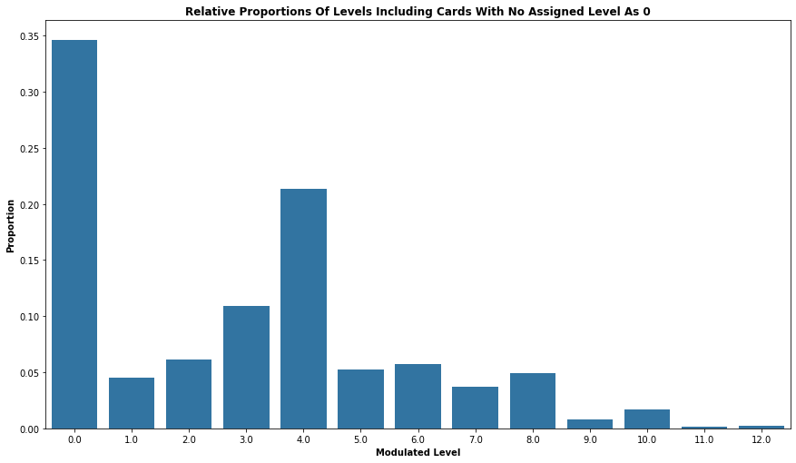

```python
my_fig()
my_count_plot(df=df,x='modulation')
plt.yticks(my_ticks* total_cards, ticks_names)
my_axis(y = 'Proportion',x = 'modulated level',
        title = "relative proportions of levels including cards with no assigned level as 0");
```

Trap Cards, Spell Cards, Tokens are more than 30% of the cards and they dont have ATK or DEF

```python
# making sure none of the three types have value within attack
df.query("card_type == 'Trap Card'")['attack'].max()
```

```
nan
```

```python
df.query("card_type == 'Spell Card'")['attack'].max()
```

```
nan
```

```python
df.query("card_type == 'Token'")['attack'].max()
```

```
nan
```

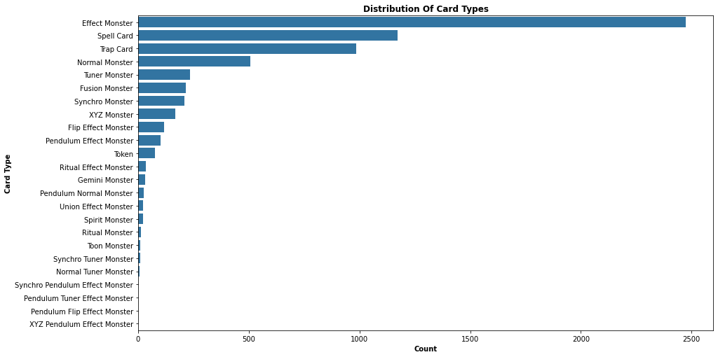

```python
my_fig()
type_count = df.card_type.value_counts()
type_order = type_count.index
my_count_plot(df=df, y='card_type',order= type_order)
my_axis(y='card type', x = 'count', title='distribution of card Types')
```

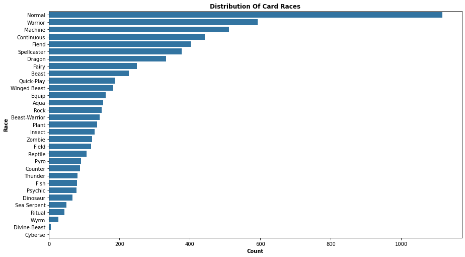

```python
my_fig()
race_count = df.race.value_counts()
race_order = race_count.index
my_count_plot(df=df, y='race', order= race_order)
my_axis(x= 'count', y = 'race', title='distribution of card races')
```

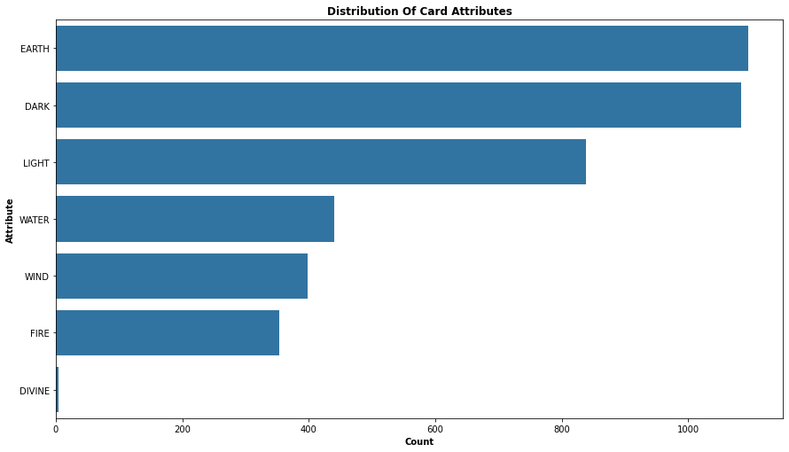

```python
my_fig()
attribute_count = df.attribute.value_counts()
attribute_order = attribute_count.index
my_count_plot(df=df, y='attribute', order= attribute_order)
my_axis(y='attribute', x='count' ,title='distribution of card attributes')
```

Divine cards have the lowest count.

```python
attribute_atk_def_mean = df.groupby('attribute')[['attack','defense']].mean()
attribute_atk_def_mean
```

| attribute | attack | defense |
| --- | --- | --- |
| DARK | 1488.966790 | 1192.278598 |
| DIVINE | 1600.000000 | 1600.000000 |
| EARTH | 1338.767123 | 1210.392694 |
| FIRE | 1543.626062 | 1151.274788 |
| LIGHT | 1526.638856 | 1254.290822 |
| WATER | 1404.761905 | 1198.185941 |
| WIND | 1423.366834 | 1181.155779 |

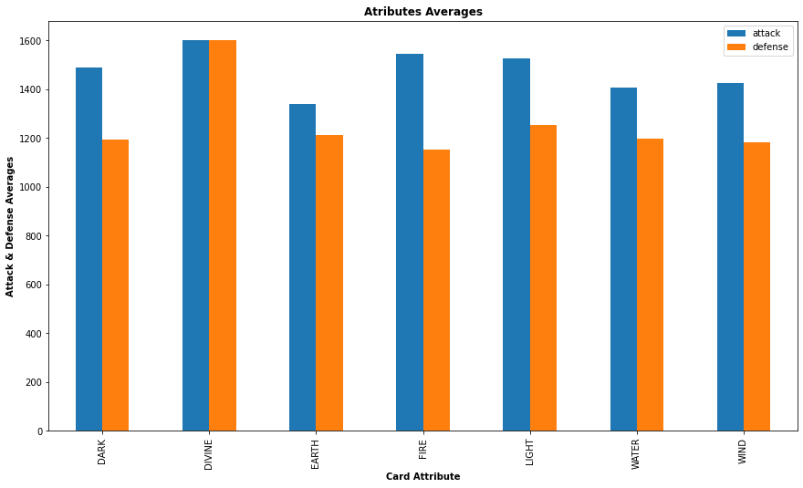

```python
attribute_atk_def_mean.plot.bar(figsize=(14.70, 8.27));
my_axis(x='card attribute', y='attack & defense averages', title="Atributes averages")
```

almost all the attributes have the same average attack and defense except for the Divine cards regarding the fact they have the lowest count.

### Discuss the distribution(s) of your variable(s) of interest. Were there any unusual points? Did you need to perform any transformations?

Level is going from 1 to 12 with Lvl 4 having the maximum number of cards and the three Types with no lvl assigned. need to remove them.

### Of the features you investigated, were there any unusual distributions? Did you perform any operations on the data to tidy, adjust, or change the form of the data? If so, why did you do this?

investigated the Level, lvl 4 have the highest number of cards skewing the distribution to the right changed the Nans to Lvl 0 for better representation of the data.

## Bivariate Exploration

Since lvl 0 has no atk or defense its better to remove them.

```python
#droping cards with Nan values in the dataset "trap, spell and token"
no_level.index
df2 = df.drop(no_level.index)
df2.head()
```

|  | name | card_type | level | race | attribute | attack | defense | modulation |
| --- | --- | --- | --- | --- | --- | --- | --- | --- |
| 1 | The 13th Grave | Normal Monster | 3.0 | Zombie | DARK | 1200.0 | 900.0 | 3.0 |
| 4 | Castle of Dark Illusions | Flip Effect Monster | 4.0 | Fiend | DARK | 920.0 | 1930.0 | 4.0 |
| 6 | Lava Golem | Effect Monster | 8.0 | Fiend | FIRE | 3000.0 | 2500.0 | 8.0 |
| 8 | Seismic Crasher | Effect Monster | 3.0 | Rock | EARTH | 1400.0 | 300.0 | 3.0 |
| 9 | Laval Lancelord | Effect Monster | 6.0 | Warrior | FIRE | 2100.0 | 200.0 | 6.0 |

```python
df2.info()
```

```
<class 'pandas.core.frame.DataFrame'>
Int64Index: 4215 entries, 1 to 6522
Data columns (total 8 columns):
 #   Column      Non-Null Count  Dtype
---  ------      --------------  -----
 0   name        4215 non-null   object
 1   card_type   4215 non-null   object
 2   level       4215 non-null   float64
 3   race        4215 non-null   object
 4   attribute   4215 non-null   object
 5   attack      4215 non-null   float64
 6   defense     4215 non-null   float64
 7   modulation  4215 non-null   float64
dtypes: float64(4), object(4)
memory usage: 296.4+ KB
```

```python
# To the reviewer, Kindly point me out why the mode have the 0 even when i removed them
lvl_mode = df2.level.mode()
lvl_mode
```

```
0    4.0
dtype: float64
```

```python
sorted(df2.level.unique())   #confirming that there is no lvl 0
```

```
[1.0, 2.0, 3.0, 4.0, 5.0, 6.0, 7.0, 8.0, 9.0, 10.0, 11.0, 12.0]
```

```python
# getting the mean and median
lvl_mean = df2.level.mean()
lvl_median = df2.level.median()
lvl_mean, lvl_median
```

```
(4.42514827995255, 4.0)
```

There is no such thing called level 4.5 so mean is useless here,

mean should be 6 but since this a right skewed graph the median would be a better choice.

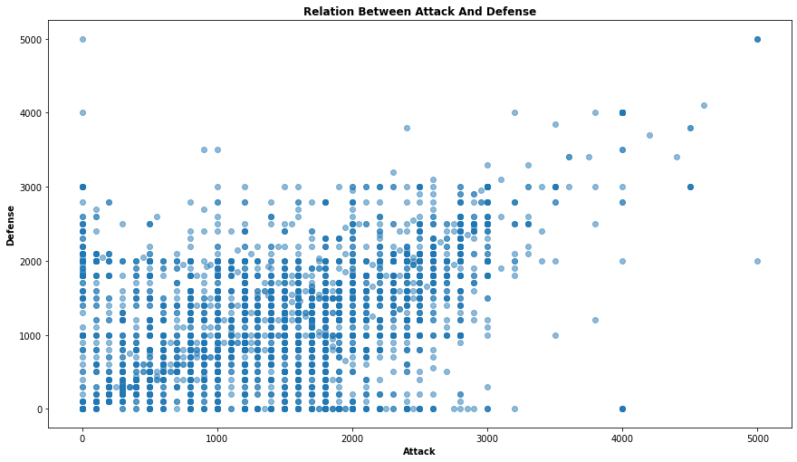

```python
def my_scatter_plot(df=df,x=None, y= None, title='', marker=None):
    my_fig()
    plt.scatter(data= df2, x=x, y =y ,alpha=0.5, marker= marker);
    plt.title(title.title(), weight='bold')

my_scatter_plot(df=df2, x = 'attack', y='defense')
my_axis(x= 'Attack', y = 'defense',title = 'Relation Between Attack and Defense')
```

Looking at the relation between ATK and DEF most of the ranging between (0,0) to (3000,3000) with few cards higher than that. with few cards with 5000 ATK and DEF , (0,5000) and (4000,0)

splitting the same graph for a better visualization.

```python
#using the median to split the dataset into high and low level cards
no_level_cards = df.query("modulation == 0").count()[0]
high_cards = df2.query("level > 4")
low_cards = df2.query("level <= 4")
high_cards_count = high_cards.count()[0]
low_cards_count = low_cards.count()[0]
```

```python
# percent of Low, high lvl cards and the ones with no level associated
total_cards = df.shape[0]
high_cards_count/total_cards, low_cards_count/total_cards, no_level_cards/total_cards
```

```
(0.22453093502868662, 0.42905876880136457, 0.34641029616994884)
```

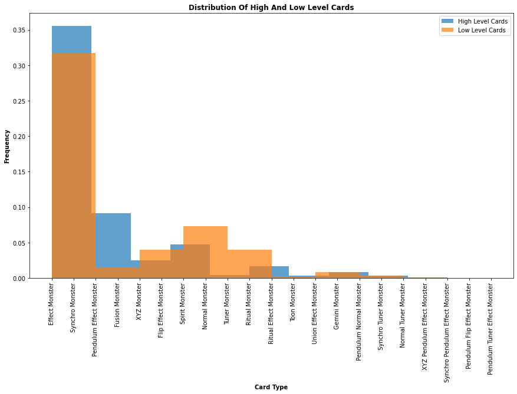

```python
# plotting high and low level cards againest each other to check the difference of distribution
order = high_cards.index
my_fig()
plt.hist(data = high_cards, x='card_type',density=True,alpha=0.7,label='High Level Cards');
plt.xticks(rotation=90);
plt.hist(data= low_cards, x='card_type', density=True,alpha =0.7, label= 'Low Level Cards');
plt.legend();
my_axis(x= 'card Type', y= 'frequency', title="Distribution of High and Low Level Cards");
```

effect monsters have a high share in both high and low cards

35% of the high lvl cards and 31% of low lvl cards

```python
#high_lvl_effect = high_cards.query("Type == 'Effect Monster'")
#low_lvl_effect = low_cards.query("Type == 'Effect Monster'")
```

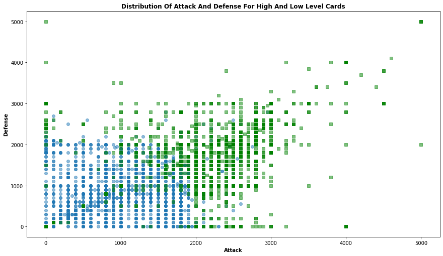

```python
my_fig()
plt.scatter(data= low_cards, x='attack', y = 'defense',alpha=0.5 );
plt.scatter(data= high_cards, x='attack', y = 'defense',alpha=0.5,marker='s',color='green');
my_axis(x='attack', y= 'defense',title= 'Distribution of Attack and Defense for High and Low Level cards')
```

as we we can see, only few cards > (2000,200) and even high atk doesnt mean high def while the majority are between (0,2000

Alot of high level cards ' green squares ' have 0 on attack and defense

```python
level_atk_def_mean = df.groupby('level')[['attack','defense']].mean()
level_atk_def_mean
```

| level | attack | defense |
| --- | --- | --- |
| 1.0 | 242.150171 | 321.843003 |
| 2.0 | 578.371501 | 601.908397 |
| 3.0 | 941.773050 | 927.021277 |
| 4.0 | 1418.001453 | 1153.510174 |
| 5.0 | 1751.681416 | 1436.578171 |
| 6.0 | 2036.585366 | 1511.869919 |
| 7.0 | 2351.470588 | 1819.117647 |
| 8.0 | 2502.380952 | 1931.428571 |
| 9.0 | 2675.471698 | 2249.056604 |
| 10.0 | 2566.055046 | 2166.972477 |
| 11.0 | 2631.250000 | 2512.500000 |
| 12.0 | 2976.470588 | 2923.529412 |

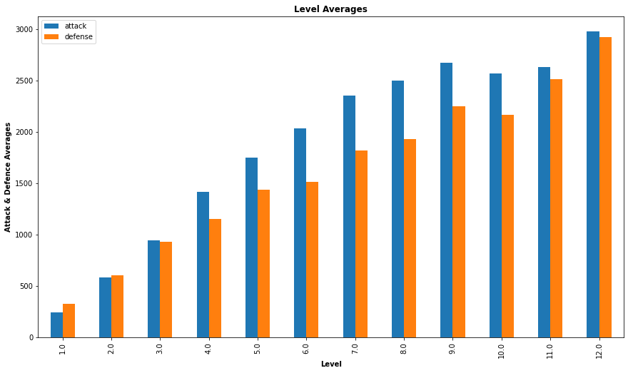

```python
level_atk_def_mean.plot.bar(figsize=(14.7,8.27));
my_axis(x='level',y='attack & defence averages', title="Level averages")
```

as expected the higher the level the higher the average attack and defense.

### Talk about some of the relationships you observed in this part of the investigation. How did the feature(s) of interest vary with other features in the dataset?

the relation between att and def seems linear.

### Did you observe any interesting relationships between the other features (not the main feature(s) of interest)?

I have to plot ATK and DEF against Level first.

## Multivariate Exploration

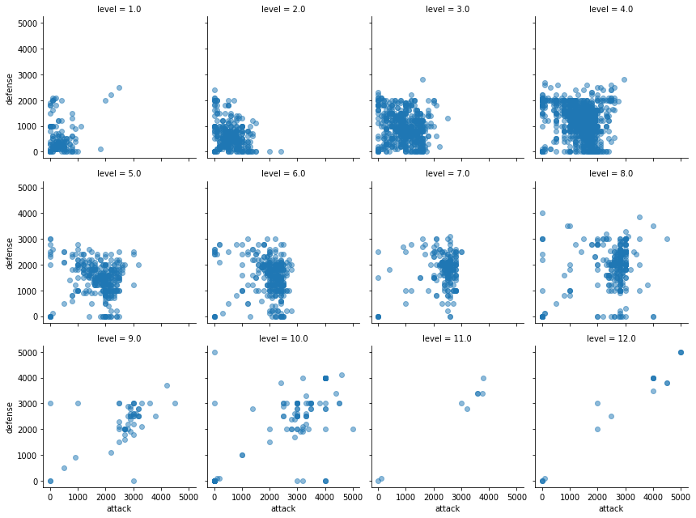

```python
g = sb.FacetGrid(data = df2, col='level',col_wrap=4,margin_titles=True);
g.map(plt.scatter, 'attack', 'defense',alpha=0.5 );
```

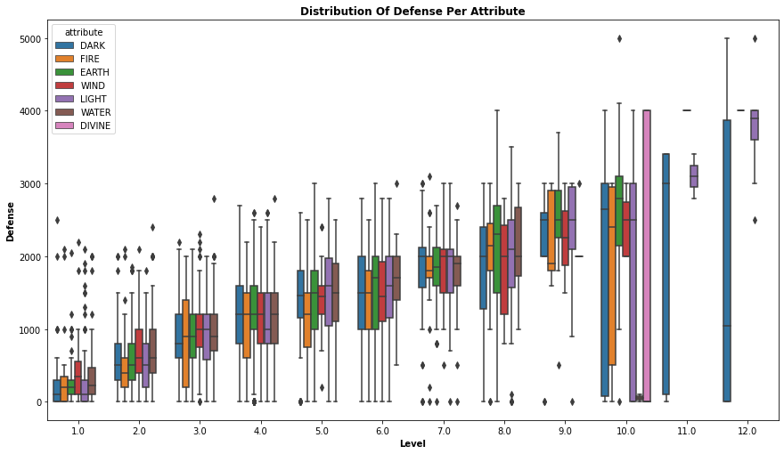

```python
my_fig()
sb.boxplot(data= df2 , x= 'level', y = 'defense', hue='attribute' );
my_axis(x= 'Level', y = 'defense', title='distribution of defense per attribute')
```

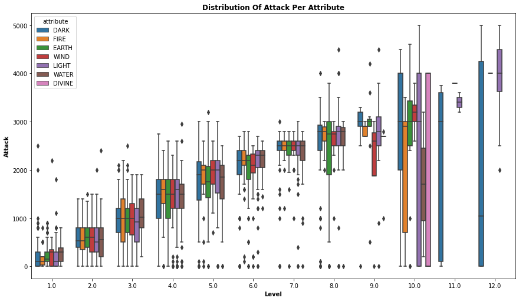

```python
my_fig()
sb.boxplot(data= df2 , x= 'level', y = 'attack', hue='attribute' );
my_axis(x= 'Level', y = 'attack', title='distribution of attack per attribute')
```

```python
df.query("level == (5,6,7,8,9,10,11,12)").count()[0] ,df.query("level == (1,2,3,4)").count()[0]
```

```
(1448, 2767)
```

giving the fact i removed the lvl 0 cards

Side Note :

even though "Exodia the Forbidden One" is one of the powerful cards in the game its only level 3 with (1000,1000) only summoned if u have its 4 parts within ur hand and The Summoner wins immidiately.

“My Grandfather’s Deck Has No Pathetic Cards, Kaiba. But It Does Contain… The Unstoppable Exodia!”

https://www.cbr.com/yugioh-best-yami-yugi-quotes-joey-wheeler-seto-kaiba/

```python
df.loc[df['name'].str.contains("forbidden one", case=False)]
```

|  | name | card_type | level | race | attribute | attack | defense | modulation |
| --- | --- | --- | --- | --- | --- | --- | --- | --- |
| 646 | Left Arm of the Forbidden One | Normal Monster | 1.0 | Spellcaster | DARK | 200.0 | 300.0 | 1.0 |
| 660 | Right Leg of the Forbidden One | Normal Monster | 1.0 | Spellcaster | DARK | 200.0 | 300.0 | 1.0 |
| 2706 | Exodia the Forbidden One | Effect Monster | 3.0 | Spellcaster | DARK | 1000.0 | 1000.0 | 3.0 |
| 3641 | Left Leg of the Forbidden One | Normal Monster | 1.0 | Spellcaster | DARK | 200.0 | 300.0 | 1.0 |
| 5694 | Right Arm of the Forbidden One | Normal Monster | 1.0 | Spellcaster | DARK | 200.0 | 300.0 | 1.0 |

Conclusion:

The attack and defense increase with level but it doesnt ensure victory due to the fact that lower level cards are more than the higher level ones. effect cards effect, trap cards and spell cards were excluded from the analysis.

Effect monsters : are the majority of cards in both high and low level cards, so it depends of how u use the cards.

Trap cards and spell cards : also flavors the game with unexpected out comes.

This analysis is limited to this dataset because alot of factors werent taken into account.

cards with attribute Divine have the lowest count but having the highest average for attack and defense